# Project 2: Investigate TMDB-Movies Dataset

1. Introduction

a. Goal of project  
b. Dataset overview

2. Data Wrangling

a. Dataset overview  
b. Assessing data  
c. Cleaning data

3. Exploratory Data Analysis

a. Research Question 1  
b. Research Question 2  
c. Research Question 3  
d. Research Question 4  
e. Research Question 5

4. Conclusions

a. Conclusion  
b. Limitation

## Introduction

### a. Goal of project

- In this project, we will analyze the TMDB-Movies Dataset by using the Python libraries NumPy, pandas, and Matplotlib.
- Some questions about this dataset:
  - Research Question 1. Which films have the highest revenue over the time? Who are the most popular directors and casts in the highest revenue films and over time?
  - Research Question 2: How is the trend of genres of films over the time?
  - Research Question 3: The trend of runtime over time and its relationship with revenue?
  - Research Question 4: The trend of budget and revenue over time and relationship between budget and revenue?
  - Research Question 5: The relationship among vote_count, vote_average, and revenue_adjusted

### b. Dataset overview

```python
# Use this cell to set up import statements for all of the packages that you
#   plan to use.

import pandas as pd
import numpy as np
import unicodedata
import matplotlib.pyplot as plt
from datetime import datetime
import seaborn as sns
```

## Data Wrangling

### a. Dataset overview

```python
input0 = pd.read_csv('tmdb-movies.csv')
input0.info()
```

```
<class 'pandas.core.frame.DataFrame'>
RangeIndex: 10866 entries, 0 to 10865
Data columns (total 21 columns):
id                      10866 non-null int64
imdb_id                 10856 non-null object
popularity              10866 non-null float64
budget                  10866 non-null int64
revenue                 10866 non-null int64
original_title          10866 non-null object
cast                    10790 non-null object
homepage                2936 non-null object
director                10822 non-null object
tagline                 8042 non-null object
keywords                9373 non-null object
overview                10862 non-null object
runtime                 10866 non-null int64
genres                  10843 non-null object
production_companies    9836 non-null object
release_date            10866 non-null object
vote_count              10866 non-null int64
vote_average            10866 non-null float64
release_year            10866 non-null int64
budget_adj              10866 non-null float64
revenue_adj             10866 non-null float64
dtypes: float64(4), int64(6), object(11)
memory usage: 1.7+ MB
```

```python
input0.describe()
```

|  | id | popularity | budget | revenue | runtime | vote_count | vote_average | release_year | budget_adj | revenue_adj |
| --- | --- | --- | --- | --- | --- | --- | --- | --- | --- | --- |
| count | 10866.000000 | 10866.000000 | 1.086600e+04 | 1.086600e+04 | 10866.000000 | 10866.000000 | 10866.000000 | 10866.000000 | 1.086600e+04 | 1.086600e+04 |
| mean | 66064.177434 | 0.646441 | 1.462570e+07 | 3.982332e+07 | 102.070863 | 217.389748 | 5.974922 | 2001.322658 | 1.755104e+07 | 5.136436e+07 |
| std | 92130.136561 | 1.000185 | 3.091321e+07 | 1.170035e+08 | 31.381405 | 575.619058 | 0.935142 | 12.812941 | 3.430616e+07 | 1.446325e+08 |
| min | 5.000000 | 0.000065 | 0.000000e+00 | 0.000000e+00 | 0.000000 | 10.000000 | 1.500000 | 1960.000000 | 0.000000e+00 | 0.000000e+00 |
| 25% | 10596.250000 | 0.207583 | 0.000000e+00 | 0.000000e+00 | 90.000000 | 17.000000 | 5.400000 | 1995.000000 | 0.000000e+00 | 0.000000e+00 |
| 50% | 20669.000000 | 0.383856 | 0.000000e+00 | 0.000000e+00 | 99.000000 | 38.000000 | 6.000000 | 2006.000000 | 0.000000e+00 | 0.000000e+00 |
| 75% | 75610.000000 | 0.713817 | 1.500000e+07 | 2.400000e+07 | 111.000000 | 145.750000 | 6.600000 | 2011.000000 | 2.085325e+07 | 3.369710e+07 |
| max | 417859.000000 | 32.985763 | 4.250000e+08 | 2.781506e+09 | 900.000000 | 9767.000000 | 9.200000 | 2015.000000 | 4.250000e+08 | 2.827124e+09 |

```python
#we see that there are 0 values in columns revenue_adj, budget_adj and runtime which are not reasonable so we checks those.
print(input0[input0['revenue_adj']== 0].revenue_adj.count())
print(input0[input0['budget_adj']== 0].revenue_adj.count())
print(input0[input0['runtime']== 0].revenue_adj.count())
```

```
6016
5696
31
```

```python
# check about duplicate row in dataset
input0[input0.duplicated(keep=False)]
```

|  | id | imdb_id | popularity | budget | revenue | original_title | cast | homepage | director | tagline | ... | overview | runtime | genres | production_companies | release_date | vote_count | vote_average | release_year | budget_adj | revenue_adj |
| --- | --- | --- | --- | --- | --- | --- | --- | --- | --- | --- | --- | --- | --- | --- | --- | --- | --- | --- | --- | --- | --- |
| 2089 | 42194 | tt0411951 | 0.59643 | 30000000 | 967000 | TEKKEN | Jon Foo\|Kelly Overton\|Cary-Hiroyuki Tagawa\|Ian... | NaN | Dwight H. Little | Survival is no game | ... | In the year of 2039, after World Wars destroy ... | 92 | Crime\|Drama\|Action\|Thriller\|Science Fiction | Namco\|Light Song Films | 3/20/10 | 110 | 5.0 | 2010 | 30000000.0 | 967000.0 |
| 2090 | 42194 | tt0411951 | 0.59643 | 30000000 | 967000 | TEKKEN | Jon Foo\|Kelly Overton\|Cary-Hiroyuki Tagawa\|Ian... | NaN | Dwight H. Little | Survival is no game | ... | In the year of 2039, after World Wars destroy ... | 92 | Crime\|Drama\|Action\|Thriller\|Science Fiction | Namco\|Light Song Films | 3/20/10 | 110 | 5.0 | 2010 | 30000000.0 | 967000.0 |

2 rows × 21 columns

```python
input0.head(2)
```

|  | id | imdb_id | popularity | budget | revenue | original_title | cast | homepage | director | tagline | ... | overview | runtime | genres | production_companies | release_date | vote_count | vote_average | release_year | budget_adj | revenue_adj |
| --- | --- | --- | --- | --- | --- | --- | --- | --- | --- | --- | --- | --- | --- | --- | --- | --- | --- | --- | --- | --- | --- |
| 0 | 135397 | tt0369610 | 32.985763 | 150000000 | 1513528810 | Jurassic World | Chris Pratt\|Bryce Dallas Howard\|Irrfan Khan\|Vi... | http://www.jurassicworld.com/ | Colin Trevorrow | The park is open. | ... | Twenty-two years after the events of Jurassic ... | 124 | Action\|Adventure\|Science Fiction\|Thriller | Universal Studios\|Amblin Entertainment\|Legenda... | 6/9/15 | 5562 | 6.5 | 2015 | 1.379999e+08 | 1.392446e+09 |
| 1 | 76341 | tt1392190 | 28.419936 | 150000000 | 378436354 | Mad Max: Fury Road | Tom Hardy\|Charlize Theron\|Hugh Keays-Byrne\|Nic... | http://www.madmaxmovie.com/ | George Miller | What a Lovely Day. | ... | An apocalyptic story set in the furthest reach... | 120 | Action\|Adventure\|Science Fiction\|Thriller | Village Roadshow Pictures\|Kennedy Miller Produ... | 5/13/15 | 6185 | 7.1 | 2015 | 1.379999e+08 | 3.481613e+08 |

2 rows × 21 columns

### b. Assessing data

> At the first look, we can see that the data hat 21 columns and 10866 rows.

### c. Data Cleaning

```python
# 1. drop some unnecessary columns: imdb_id, budget, revenue, homepage, tagline,overview
input= input0.drop(columns=['imdb_id', 'budget', 'revenue', 'homepage', 'tagline','overview'])
```

```python
# 2. cleaning quality problems
input['release_date']=pd.to_datetime(input['release_date'])
input['revenue_adj'].replace(0,np.NaN, inplace =True)
input['budget_adj'].replace(0,np.NaN, inplace =True)
input['runtime'].replace(0,np.NaN, inplace =True)
input = input.dropna(axis=0,subset=['revenue_adj','budget_adj','runtime'])
```

```python
# 3. cleaing tidiness problems
input.drop_duplicates(inplace=True)
input_new = (input.genres.str.split('|', expand= True).add_prefix('genres_'))
input_genres0=pd.get_dummies(input_new['genres_0'])
input_genres1=pd.get_dummies(input_new['genres_1'])
input_genres2=pd.get_dummies(input_new['genres_2'])
input_genres3=pd.get_dummies(input_new['genres_3'])
input_genres4=pd.get_dummies(input_new['genres_4'])

df_col = pd.concat([input['id'],input_genres0,input_genres1,input_genres2,input_genres3,input_genres4], axis=1)
input_genres =df_col.groupby(level=0, axis=1).sum()
input_genres = input_genres.reindex(columns = ['id','Action', 'Adventure', 'Animation', 'Comedy', 'Crime', 'Documentary',
       'Drama', 'Family', 'Fantasy', 'Foreign', 'History', 'Horror', 'Music','Mystery', 'Romance', 'Science Fiction',
        'TV Movie', 'Thriller', 'War', 'Western'])
input_genres.head(5)
```

|  | id | Action | Adventure | Animation | Comedy | Crime | Documentary | Drama | Family | Fantasy | ... | History | Horror | Music | Mystery | Romance | Science Fiction | TV Movie | Thriller | War | Western |
| --- | --- | --- | --- | --- | --- | --- | --- | --- | --- | --- | --- | --- | --- | --- | --- | --- | --- | --- | --- | --- | --- |
| 0 | 135397 | 1 | 1 | 0 | 0 | 0 | 0 | 0 | 0 | 0 | ... | 0 | 0 | 0 | 0 | 0 | 1 | 0 | 1 | 0 | 0 |
| 1 | 76341 | 1 | 1 | 0 | 0 | 0 | 0 | 0 | 0 | 0 | ... | 0 | 0 | 0 | 0 | 0 | 1 | 0 | 1 | 0 | 0 |
| 2 | 262500 | 0 | 1 | 0 | 0 | 0 | 0 | 0 | 0 | 0 | ... | 0 | 0 | 0 | 0 | 0 | 1 | 0 | 1 | 0 | 0 |
| 3 | 140607 | 1 | 1 | 0 | 0 | 0 | 0 | 0 | 0 | 1 | ... | 0 | 0 | 0 | 0 | 0 | 1 | 0 | 0 | 0 | 0 |
| 4 | 168259 | 1 | 0 | 0 | 0 | 1 | 0 | 0 | 0 | 0 | ... | 0 | 0 | 0 | 0 | 0 | 0 | 0 | 1 | 0 | 0 |

5 rows × 21 columns

## Exploratory Data Analysis

> **Tip**: Now that you've trimmed and cleaned your data, you're ready to move on to exploration. Compute statistics and create visualizations with the goal of addressing the research questions that you posed in the Introduction section. It is recommended that you be systematic with your approach. Look at one variable at a time, and then follow it up by looking at relationships between variables.

### Research Question 1: Which films have the highest revenue over the time? Who are the most popular directors and casts in the highest revenue films and over time?

> With the Table 1 following, we can see that Top 10 highest revenue film over the time. Out of them, Avatar released 2009 places at the place 1, followings are StarWars 1977 and Titanic 1997. At this table, we have some first view about the `adjusted budget`, `adjusted revenue` and the `casts` of these high revenue films.

> In Table 2: We can see clearly that most of the highest revenue films are `Adventure`, `Action`, `Science Fiction`. Other kinds of genres specially `Comedy`, `Romance` and so accounts only a small part, or perhaps play only a not-very- important role for such a successful film. However when we look into Table 3, We can see genres like `drama`, `comedy` at the Top 2 of the number of films that have been made over time.

> For the `cast` in these films, I list only some casts, but acctually there more than 42 casts playing in these films. Most of them are very famous. Meanwhile in Table 3, the Top 10 popular casts over time are shown with the number of films they played.

> In Table 2, we can see the name of `director`, who have made the highest revenue films, whereas in Table 3, the most popular directors over time are also shown. Out of them, `James Cameron` and `Steven Spielberg` are of course the most famous ones.

```python
#Table 1
df_r=input[['original_title','release_year', 'budget_adj', 'revenue_adj', 'genres', 'director', 'cast', 'keywords']].sort_values(by=['revenue_adj']).nlargest(10, 'revenue_adj')
df_r1=df_r[['original_title', 'release_year','budget_adj','revenue_adj', 'cast']].set_index('original_title')
print('Table 1: Overview \n')
df_r1
```

```
Table 1: Overview
```

| original_title | release_year | budget_adj | revenue_adj | cast |
| --- | --- | --- | --- | --- |
| Avatar | 2009 | 2.408869e+08 | 2.827124e+09 | Sam Worthington\|Zoe Saldana\|Sigourney Weaver\|S... |
| Star Wars | 1977 | 3.957559e+07 | 2.789712e+09 | Mark Hamill\|Harrison Ford\|Carrie Fisher\|Peter ... |
| Titanic | 1997 | 2.716921e+08 | 2.506406e+09 | Kate Winslet\|Leonardo DiCaprio\|Frances Fisher\|... |
| The Exorcist | 1973 | 3.928928e+07 | 2.167325e+09 | Linda Blair\|Max von Sydow\|Ellen Burstyn\|Jason ... |
| Jaws | 1975 | 2.836275e+07 | 1.907006e+09 | Roy Scheider\|Robert Shaw\|Richard Dreyfuss\|Lorr... |
| Star Wars: The Force Awakens | 2015 | 1.839999e+08 | 1.902723e+09 | Harrison Ford\|Mark Hamill\|Carrie Fisher\|Adam D... |
| E.T. the Extra-Terrestrial | 1982 | 2.372625e+07 | 1.791694e+09 | Henry Thomas\|Drew Barrymore\|Robert MacNaughton... |
| The Net | 1995 | 3.148127e+07 | 1.583050e+09 | Sandra Bullock\|Jeremy Northam\|Dennis Miller\|We... |
| One Hundred and One Dalmatians | 1961 | 2.917944e+07 | 1.574815e+09 | Rod Taylor\|J. Pat O'Malley\|Betty Lou Gerson\|Ma... |
| The Avengers | 2012 | 2.089437e+08 | 1.443191e+09 | Robert Downey Jr.\|Chris Evans\|Mark Ruffalo\|Chr... |

```python
#Table 2
most_popular_genres = pd.Series(df_r['genres'].str.cat(sep = '|').split('|',-1)).value_counts()
most_wanted_director =pd.Series(df_r['director'].str.cat(sep = '|').split('|',-1)).value_counts()
some_casts_in_most_revenue= pd.Series(df_r['cast'].str.cat(sep = '|').split('|', -1)).value_counts().nlargest(10)


df_most_popular_genres = most_popular_genres.rename_axis('Most_favourite_genres').reset_index(name='Number of films')
df_most_wanted_directorR = most_wanted_director.rename_axis('Most_favourite_director').reset_index(name='Number of films')
df_some_casts_in_highest_revenue = some_casts_in_most_revenue.rename_axis('Most_popular_casts').reset_index(name='Number of films')

from IPython.display import display_html
def display_side_by_side(*args):
    html_str=''
    for df in args:
        html_str+=df.to_html()
    display_html(html_str.replace('table','table style="display:inline"'),raw=True)
print('Table 2: Genres, Directors and Casts in 10 highest revenue films')
display_side_by_side(  df_most_popular_genres, df_some_casts_in_highest_revenue, df_most_wanted_directorR)

#Table 3
most_popular_genres = pd.Series(input['genres'].str.cat(sep = '|').split('|',-1)).value_counts().nlargest(10)
most_wanted_director =pd.Series(input['director'].str.cat(sep = '|').split('|',-1)).value_counts().nlargest(10)
popular_casts= pd.Series(input['cast'].str.cat(sep = '|').split('|', -1)).value_counts().nlargest(10)


df_most_popular_genres = most_popular_genres.rename_axis('Most_favourite_genres').reset_index(name='Number of films')
df_most_wanted_director = most_wanted_director.rename_axis('Most_favourite_director').reset_index(name='Number of films')
df_popular_casts = popular_casts.rename_axis('Most_popular_casts').reset_index(name='Number of films')

from IPython.display import display_html
def display_side_by_side(*args):
    html_str=''
    for df in args:
        html_str+=df.to_html()
    display_html(html_str.replace('table','table style="display:inline"'),raw=True)
print( '\n Table3: Top 10 Genres, Directors and Casts over the time:')
display_side_by_side(  df_most_popular_genres, df_popular_casts, df_most_wanted_director)
```

```
Table 2: Genres, Directors and Casts in 10 highest revenue films
```

|  | Most_favourite_genres | Number of films |
| --- | --- | --- |
| 0 | Adventure | 7 |
| 1 | Action | 5 |
| 2 | Science Fiction | 5 |
| 3 | Thriller | 4 |
| 4 | Drama | 3 |
| 5 | Fantasy | 3 |
| 6 | Horror | 2 |
| 7 | Family | 2 |
| 8 | Crime | 1 |
| 9 | Romance | 1 |
| 10 | Comedy | 1 |
| 11 | Animation | 1 |
| 12 | Mystery | 1 |

|  | Most_popular_casts | Number of films |
| --- | --- | --- |
| 0 | Carrie Fisher | 2 |
| 1 | Harrison Ford | 2 |
| 2 | Mark Hamill | 2 |
| 3 | Chris Hemsworth | 1 |
| 4 | Richard Dreyfuss | 1 |
| 5 | Max von Sydow | 1 |
| 6 | Jeremy Northam | 1 |
| 7 | Sam Worthington | 1 |
| 8 | Betty Lou Gerson | 1 |
| 9 | Michelle Rodriguez | 1 |

|  | Most_favourite_director | Number of films |
| --- | --- | --- |
| 0 | James Cameron | 2 |
| 1 | Steven Spielberg | 2 |
| 2 | Hamilton Luske | 1 |
| 3 | Joss Whedon | 1 |
| 4 | J.J. Abrams | 1 |
| 5 | Irwin Winkler | 1 |
| 6 | Clyde Geronimi | 1 |
| 7 | William Friedkin | 1 |
| 8 | George Lucas | 1 |
| 9 | Wolfgang Reitherman | 1 |

```
 Table3: Top 10 Genres, Directors and Casts over the time:
```

|  | Most_favourite_genres | Number of films |
| --- | --- | --- |
| 0 | Drama | 1756 |
| 1 | Comedy | 1358 |
| 2 | Thriller | 1204 |
| 3 | Action | 1085 |
| 4 | Adventure | 749 |
| 5 | Romance | 667 |
| 6 | Crime | 651 |
| 7 | Science Fiction | 519 |
| 8 | Horror | 463 |
| 9 | Family | 425 |

|  | Most_popular_casts | Number of films |
| --- | --- | --- |
| 0 | Robert De Niro | 52 |
| 1 | Bruce Willis | 46 |
| 2 | Samuel L. Jackson | 44 |
| 3 | Nicolas Cage | 43 |
| 4 | Matt Damon | 36 |
| 5 | Johnny Depp | 35 |
| 6 | Sylvester Stallone | 34 |
| 7 | Tom Hanks | 34 |
| 8 | Harrison Ford | 34 |
| 9 | Morgan Freeman | 34 |

|  | Most_favourite_director | Number of films |
| --- | --- | --- |
| 0 | Steven Spielberg | 28 |
| 1 | Clint Eastwood | 24 |
| 2 | Ridley Scott | 21 |
| 3 | Woody Allen | 18 |
| 4 | Steven Soderbergh | 17 |
| 5 | Robert Rodriguez | 17 |
| 6 | Tim Burton | 17 |
| 7 | Martin Scorsese | 17 |
| 8 | Renny Harlin | 15 |
| 9 | Brian De Palma | 15 |

```python
df=pd.DataFrame({'x' : input.release_year.sort_values(),
                'Drama'         :input_genres['Drama'],
                'Comedy'       :input_genres['Comedy'],
                'Thriller'     :input_genres['Thriller'],
                'Action'        :input_genres['Action'],
                'Adventure'       :input_genres['Adventure'],
                'Fiction':input_genres['Science Fiction'],
                'Crime'      :input_genres['Crime'],
                'Romance'       :input_genres['Romance'],
                'Horror'        :input_genres['Horror'],
                'Mystery'       :input_genres['Mystery'],
                'Family'        :input_genres['Family'],
                'Horror'       :input_genres['Fantasy'],
                'Animation'     :input_genres['Animation'],
                'Music'         :input_genres['Music'],
                'Documentary'    :input_genres['Documentary'],
                'War'           :input_genres['War'] ,
                'History'       :input_genres['History'],
                'Western'       :input_genres['Western'],
                'Foreign'       :input_genres['Foreign'],
                'TV Movie'     :input_genres['TV Movie']
                }).apply(lambda x : x.astype('int64')).groupby(['x']).sum()
```

### Research Question 2: How is the trend of genres of films over the time?

> With the line chart, we can see clearly trend of genres over time. As mentioned above, `drame` are the favorite one of directors, this kind of films are made more and more from years to years. The followings are `comedy`, `thriller` and `action`.

```
Chart1
```

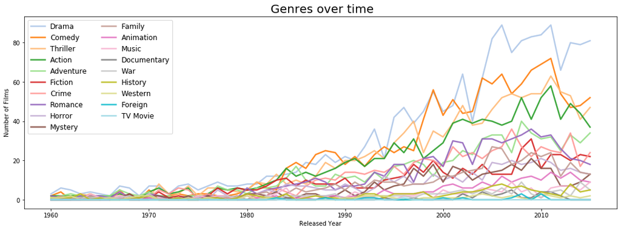

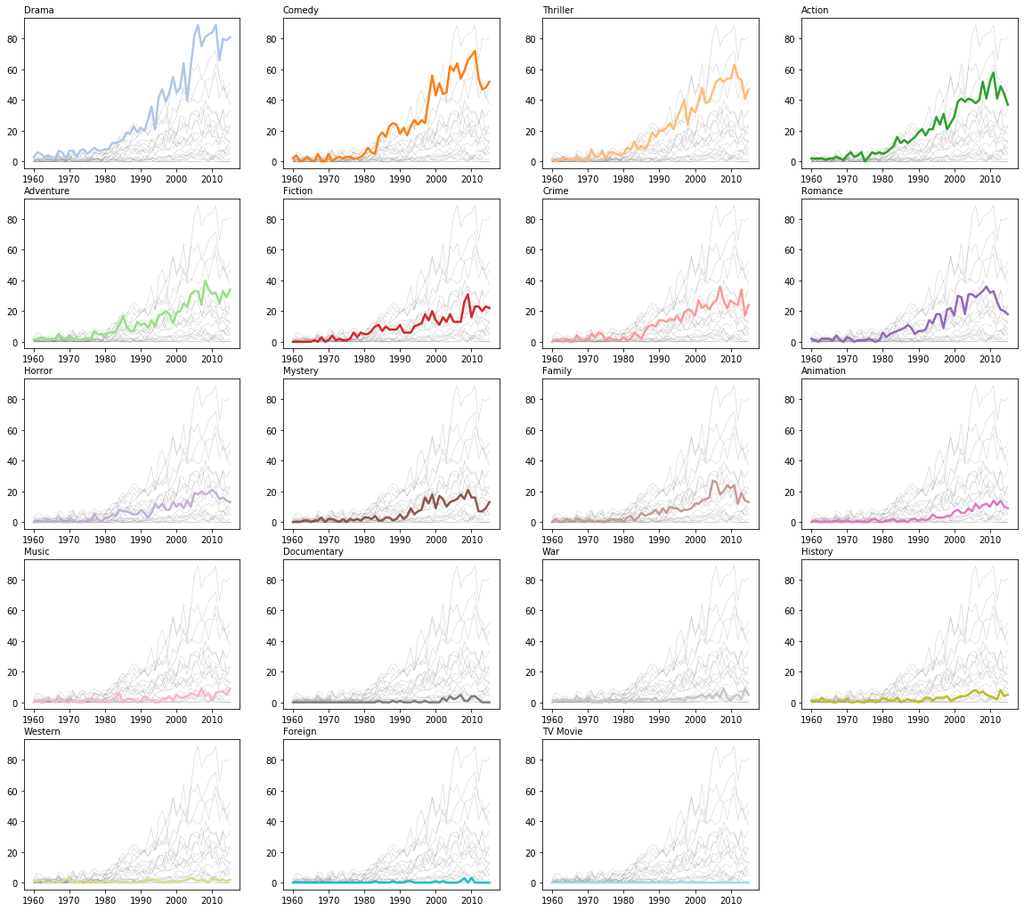

```python
print('Chart1')
fig = plt.figure(figsize=(18,6))
xx=df.index.get_level_values(0).tolist()
num=0
for column in df:
    num+=1
    plt.plot( xx,df[column], marker='', color=palette(num), linewidth=2.5, alpha=0.9, label=column)
plt.legend(loc=2, ncol=2,fontsize=12)

plt.title(" Genres over time", loc='center', fontsize=20, fontweight=0)
plt.xlabel("Released Year")
plt.ylabel("Number of Films")

fig = plt.figure(figsize=(20,18))
num=0
for column in df:
    num+=1
    plt.subplot(5,4,num)
    for v in df:
        plt.plot(xx, df[v], marker='', color='grey', linewidth=0.5, alpha=0.4)
    plt.plot(xx, df[column], marker='', color=palette(num), linewidth=2.5, alpha=1, label=column)
    plt.title(column, loc='left', fontsize=10, fontweight=0 )

fig.subplots_adjust(hspace=0.2)
plt.show()
```

### Research Question 3: The trend of runtime over time and its relationship with revenue?

> With Chart 2, we can see the trend of runtime over years, it is a decreasing trend in runtime, its plunged to the bottom in the later 80s and from then, most of films have average runtime of around 100 minutes which can be seen clearly in Chart 3.

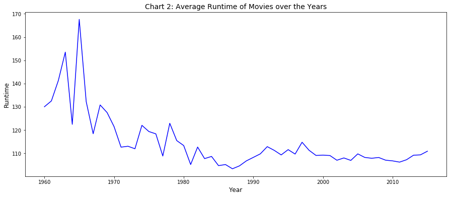

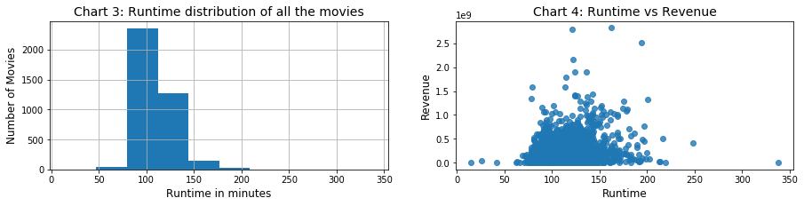

```python
# Continue to explore the data to address your additional research
#   questions. Add more headers as needed if you have more questions to
#   invaestigate.
input.groupby('release_year')['runtime'].mean().plot(kind='line', figsize = (15, 6), color = 'blue')
plt.title('Chart 2: Average Runtime of Movies over the Years', fontsize = 14)
plt.xlabel('Year', fontsize = 12)
plt.ylabel('Runtime', fontsize = 12)

fig = plt.figure(figsize=(15,8))
plt.subplot(2,2,1)
input['runtime'].hist( )
plt.xlabel('Runtime in minutes', fontsize = 12)
plt.ylabel('Number of Movies', fontsize=12)
plt.title('Chart 3: Runtime distribution of all the movies', fontsize=14)


plt.subplot(2,2,2)
sns.regplot(x = input['runtime'], y = input['revenue_adj'], fit_reg = False)
#plt.rcParams["figure.figsize"] = fig_size
plt.title('Chart 4: Runtime vs Revenue', fontsize = 14)
plt.xlabel('Runtime', fontsize = 12)
plt.ylabel('Revenue', fontsize = 12)

fig.subplots_adjust(wspace=0.2)
fig.subplots_adjust(hspace=0.6)
plt.show()
```

### Research Question 4: The trend of budget and revenue over time and relationship between budget and revenue?

> In Chart 5, it is interesting that the adjusted revenue of films before 80s are higher than the one of nowaday films. However it can be understandable because the number of films nowaday is quite larger than before, the revenue gap between films are also quite high, so it is possible that the average revenue of a film nowaday is lower than before. Meanwhile the budget spending for 1 film seems to be quite stable over time. It stays always under USD 1e8 (at around 4.4e07).

> Chart 6, Chart 7, Chart 8 give us a better view about the relationship between budget and revenue. With chart 6, we can see that the revenue are not always parrarel with budget. There are films with small budget but gaining high revenue. Some of them are `Star War` or `The Exorcist`. In contrast, some films like `The Warrior's Way` having the largest `budget` over time, but revenue is very low.

```
budget_adj     4.423999e+07
revenue_adj    1.370647e+08
dtype: float64
```

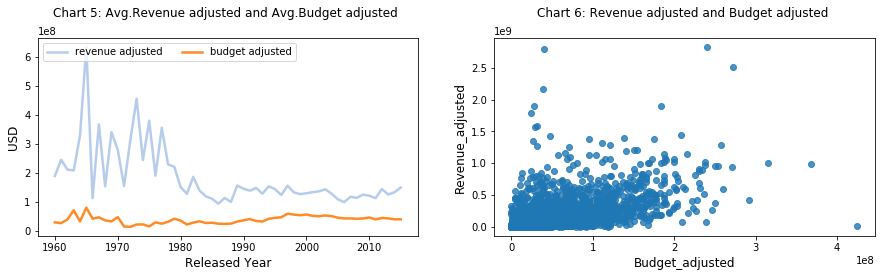

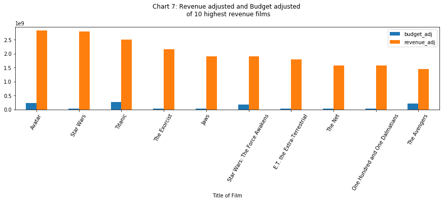

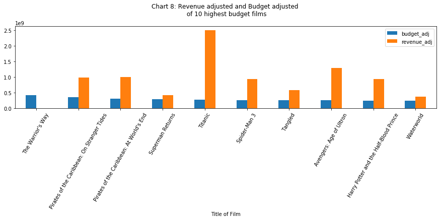

```python
fig = plt.figure(figsize=(15,8))
plt.subplot(2,2,1)
df=pd.DataFrame({'x' : input.release_year.sort_values(),
                 'revenue adjusted':input['revenue_adj'],
                 'budget adjusted':input['budget_adj']}).groupby(['x']).mean()

palette = plt.get_cmap('tab20')
xx=df.index.get_level_values(0).tolist()
num=0
print(input[['budget_adj','revenue_adj']].mean())
for column in df:
    num+=1
    plt.plot( xx,df[column], marker='', color=palette(num), linewidth=2.5, alpha=0.9, label=column)
plt.legend(loc=2, ncol=2)
plt.xlabel("Released Year",fontsize = 12)
plt.ylabel("USD",fontsize = 12)
plt.title("Chart 5: Avg.Revenue adjusted and Avg.Budget adjusted \n", loc='center', fontsize=12, fontweight=0)


plt.subplot(2,2,2)
a=sns.regplot(x = input['budget_adj'], y = input['revenue_adj'], fit_reg = False)
plt.xlabel('Budget_adjusted', fontsize = 12)
plt.ylabel('Revenue_adjusted', fontsize = 12)
plt.title("Chart 6: Revenue adjusted and Budget adjusted \n", loc='center', fontsize=12, fontweight=0)


df = pd.DataFrame({'budget_adj': df_r.budget_adj,
                   'revenue_adj': df_r.revenue_adj,
                  'Title of Film': df_r.original_title }).set_index('Title of Film').sort_values(by=['revenue_adj']).nlargest(10, 'revenue_adj')
df.plot.bar(figsize=(15,3),rot=0)
plt.xticks( rotation=60,fontsize = 10 )
plt.title("Chart 7: Revenue adjusted and Budget adjusted \n of 10 highest revenue films\n",
          loc='center', fontsize=12, fontweight=0)

df = pd.DataFrame({'budget_adj': input.budget_adj,
                   'revenue_adj': input.revenue_adj,
                  'Title of Film': input.original_title }).set_index('Title of Film').sort_values(by=['budget_adj']).nlargest(10, 'budget_adj')
df.plot.bar(figsize=(15,3),rot=0)
plt.xticks( rotation=60,fontsize = 10)
plt.title("Chart 8: Revenue adjusted and Budget adjusted \n of 10 highest budget films\n",
          loc='center', fontsize=12, fontweight=0)


fig.subplots_adjust(hspace=0.2)
plt.show()
```

### Research Question 5: The relationship among vote_count, vote_average, and revenue_adjusted

[figure not shown]

```python
fig = plt.figure()
plt.subplot(2,2,1)
sns.regplot(x = input['vote_count'], y = input['vote_average'], fit_reg = False)
plt.xlabel('vote_count', fontsize = 12)
plt.ylabel('vote_average', fontsize = 12)
plt.title('Chart 9: vote_count and vote_average',
          loc='center', fontsize=12, fontweight=0)

plt.subplot(2,2,2)
sns.regplot(x = input['vote_count'], y = input['revenue_adj'], fit_reg = False)
plt.xlabel('vote_count', fontsize = 12)
plt.ylabel('Revenue_adjusted', fontsize = 12)
plt.title('Chart 10: vote_count and adjusted revenue',
          loc='center', fontsize=12, fontweight=0)

plt.subplot(2,2,3)
sns.regplot(x = input['vote_average'], y = input['revenue_adj'], fit_reg = False)
plt.xlabel('vote_average', fontsize = 12)
plt.ylabel('Revenue_adjusted', fontsize = 12)
plt.title('\n \n Chart 11: vote_average and adjusted revenue',
          loc='center', fontsize=12, fontweight=0)

plt.subplot(2,2,4)
plt.scatter(x = input[['vote_average']], y = input['revenue_adj'], s= 0.04*input['vote_count'] ,label=input['vote_count'], alpha=0.5)
plt.xlabel('vote_average', fontsize = 12)
plt.ylabel('Revenue_adjusted', fontsize = 12)
plt.title('Chart 11: Relationship among \n vote_average,vote_count and adjusted revenue',
          loc='center', fontsize=12, fontweight=0)
fig.subplots_adjust(wspace=0.2)
fig.subplots_adjust(hspace=0.4)
plt.show()
```

## Conclusions

### 1. Conclusion

In this project, we have performed all steps involved in a typical data analysis process. Beginning with placing questions which we wan to get the answer with a given dataset. Then we do data wrangling which includes data assessing, data cleaning to investigate problems. And therefore some questions about the revenue, trend of genres, runtime, revenue were placed at the beginning. Then, we also analyze some relationship with revenue as the dependent variable and its relationship with some other variables such as genres, runtime, vote_count, vote_average. After all, we can fortunately answer the questions posted at the beginning.

### 2. Limitation

With the visualization and some commands using Python libraries. We can have at first some aspects of dataset. For example, we can see almost of these variables have some impacts on revenue, but the assessing of how strong and how exact they are, were not included in this scope of project. With some more practical statistics such as regression for number variables and logistic regression for categorical variable, perhaps we can have more exact information about dataset.

## Reference:

1. https://pythonspot.com/
2. https://stackoverflow.com/
3. https://pandas.pydata.org/
4. https://datatofish.com/
5. http://www.datasciencemadesimple.com/
6. https://www.geeksforgeeks.org/
7. https://matplotlib.org/
8. and so on...